# 통계적수리기초 중간고사

Coop711

2016-04-20

학번______________

이름______________

#### 다음 물음에 답하시오.

1. $f(t)=2t+\sqrt{25-t^2}$ 의 정의역을 구하고 그 정의역에서 함수가 연속인 이유를 설명하라.
2. 모든 $x$에 대하여 $1\le f(x)\le x^2+2x+2$ 일때, $\lim_{x\rightarrow-1}f(x)$를 구하여라.
3. 만약 $a>0$이면 $\lim_{x\rightarrow a}\sqrt{x}=\sqrt{a}$
4. $f(x)=x-\frac{2}{x}$일 때 $f^\prime(x)$를 구하여라.
5. $h(x)=\frac{x+2}{x-1}$ 를 미분하여라.
6. 음함수의 미분법을 이용하여 $x^2y+xy^2=3x$에서 $\frac{dy}{dx}$을 구하시오.
7. $y=f(u)$, $u=g(x)$이다. $f$와 $g$는 두번 미분가능할 때, $\frac{d^2y}{dx^2}=\frac{d^2y}{du^2}\big(\frac{du}{dx})^2+\frac{dy}{du}\frac{d^2u}{dx^2}$ 임을 보이시오.
8. $f(x)=\frac{x}{1+x^2}$에 대하여
1. $f$가 증가 또는 감소하는 구간을 구하시오.
2. $f$의 극대값과 극소값을 구하시오.
3. 오목성의 구간과 변곡점을 구하시오.
9. $\lim_{x\rightarrow\infty}\big(\sqrt{x^2+3x+1}-x\big)$ 를 구하시오.
10. 다음 코드와 그림을 보고 물음에 답하시오.

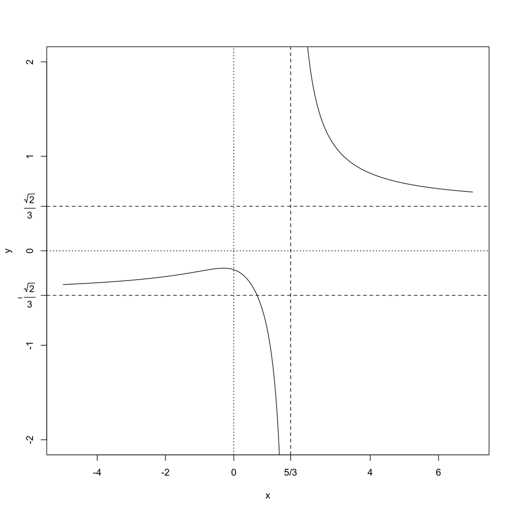

```r
x <- sort(c(seq(-5, 7, length = 1000), 5/3))
f.3.4 <- function(x){
  (sqrt(2*x^2 + 1))/(3*x - 5)
  }
y <- f.3.4(x)
plot(x, y, type = "l", ylim = c(-2, 2), xaxt = "n")
abline(h = 0, v = 0, lty = 3)
abline(h = c(-sqrt(2)/3, sqrt(2)/3), v =  5/3, lty = 2)
axis(side = 1, at = c(-4, -2, 0, 5/3, 4, 6) , labels = c(-4, -2, 0, "5/3", 4, 6))
axis(side = 2, at = c(-sqrt(2)/3, sqrt(2)/3), labels = c(expression(-frac(sqrt(2),3)), expression(frac(sqrt(2), 3))), las = 1)
```

1. `x`값을 설정하는 데 $\frac{5}{3}$ 를 따로 넣은 것은 다음 중 어느 조건으로부터 비롯된 그래프 외관의 문제를 해결하기 위함인가?

   가. `x, y`

   나. `type = "l"`

   다. `ylim = c(-2, 2)`

   라. `xaxt = "n"`
2. $x$ 축에 label을 붙이는데 중간에 `"5/3"`이 들어간 이유를 간단히 설명하시오.
3. $y$축에 $\pm\frac{\sqrt{2}}{3}$을 표현하는 데 가장 큰 역할을 하는 것은?

   가. `side = 2`

   나. `at = c(-sqrt(2)/3, sqrt(2)/3)`

   다. `labels = c(expression(-frac(sqrt(2),3)), expression(frac(sqrt(2), 3)))`

   라. `las = 1`
4. $x$축에 눈금을 사용자가 조정하기 위하여 사용한 조건은 무엇인가?

   가. `x, y`

   나. `type = "l"`

   다. `ylim = c(-2, 2)`

   라. `xaxt = "n"`
5. 원점을 중심으로 수평축과 수직축을 그리기 위해서 사용한 코드는 무엇인가?

   가. `h = 0, v = 0`

   나. `lty = 3`

   다. `v = 5/3`

   라. `lty = 2`